# time series

anil

2026-09-18

# 1. What is Time Series?

Start with a very simple question:

> **“What is special about data when time is involved?”**

Suppose an online shopping company records the number of orders every month:

| Month | Orders |
| --- | --- |
| Jan | 1,000 |
| Feb | 1,100 |
| Mar | 1,250 |
| Apr | 1,200 |
| May | 1,400 |
| Jun | 1,500 |

This is **time series data** because the observations are associated with successive points in time.

We define time series data as quantities that trace the values of a variable over a period such as **month, quarter or year**. Examples given include share prices and monthly unemployment.

### Industry examples

| Industry | Time Series |
| --- | --- |
| E-commerce | Daily orders |
| Banking | Daily ATM transactions |
| Stock market | Share price every minute |
| Electricity | Power consumption every hour |
| Telecom | Number of calls per hour |
| Manufacturing | Production per day |
| Weather | Temperature every hour |
| YouTube/Netflix | Number of users per hour |

**Normal data asks:**

> What is the value?

**Time series asks:**

> What is the value, and **when did it occur?**

That “when” is extremely important.

# 2. Why do companies analyse Time Series?

time series modelling helps businesses analyse and predict things such as **sales, website traffic and competitive position**.

### Amazon-like e-commerce example

Imagine a company has the following monthly sales:

```
Jan   10 lakh
Feb   11 lakh
Mar   12 lakh
Apr   11 lakh
May   13 lakh
Jun   15 lakh
```

Management may ask:

1. Are sales increasing?
2. Is there a seasonal pattern?
3. Are there unusual sales drops?
4. What will sales be next month?
5. How much inventory should we maintain?

**Time series analysis attempts to answer these questions.**

Is there a **trend**?

- Is there **seasonality**?
- Are there **outliers**?
- Does variance change over time?
- Are there abrupt changes?

# 3. Components of Time Series

TS is describes four components:

### 1. Trend

Long-term upward or downward movement.

Example:

```
2019  100
2020  110
2021  120
2022  135
2023  150
```

The company is gradually growing.

**Industry example:** Number of smartphone users increasing over several years.

### 2. Seasonality

A pattern that repeats at regular calendar intervals.

For example, an e-commerce company may see:

```
Jan   █████
Feb   █████
Mar   ██████
...
Oct   ███████
Nov   ███████████
Dec   ██████████
```

November and December may repeatedly have higher sales because of festivals and holiday shopping.

seasonality as repeating highs and lows associated with calendar periods such as **seasons, quarters, months or days of the week**.

### 3. Cyclical variation

Longer-term fluctuations that don’t necessarily repeat at a fixed calendar interval.

**Industry example:**

During economic expansion:

```
Sales ↑
Production ↑
Employment ↑
```

During an economic slowdown:

```
Sales ↓
Production ↓
Employment ↓
```

we have to distinguishes cyclical fluctuations from seasonal variation.

### 4. Irregular component

Unexpected/random events.

For example:

> A factory normally produces 10,000 units/day.

Suddenly:

```
Monday      10,000
Tuesday     10,200
Wednesday    9,800
Thursday     2,000   ← unexpected event
Friday       10,100
```

The drop might be caused by a machine failure, strike, natural disaster, etc.

gives natural incidents and political events as examples of irregular events.

# Business planning

Consider a hotel.

Its monthly occupancy might look like:

```
Trend       → tourism is growing
Seasonality → December is busy
Cyclical    → economic conditions affect travel
Irregular   → unexpected events
```

Management can then make different decisions:

| Component | Possible business question |
| --- | --- |
| Trend | Should we expand the hotel? |
| Seasonality | How many employees do we need in December? |
| Cyclicality | How should we plan for economic slowdown? |
| Irregular | Was there an unusual event affecting demand? |

This is the **real reason for decomposition**.

Another example:

> **“Your electricity bill is ₹3,000. Why is it ₹3,000?”**

It may be because:

```
₹3,000 total
     │
     ├── Normal household usage
     │
     ├── Summer effect → AC usage (Seasonality)
     │
     ├── Long-term change → more appliances (Trend)
     │
     └── Unusual event → guests / special occasion (Irregular)
```

# 4. Univariate vs Multivariate Time Series

### Univariate

Only **one variable** is measured over time.

Example:

```
Month       Sales
Jan         100
Feb         120
Mar         130
Apr         140
```

Only sales are being studied.

### Multivariate

Multiple variables are measured over time.

```
Month   Sales   Advertising   Temperature
Jan     100     20             25
Feb     120     25             27
Mar     130     30             30
```

whether a single quantity or more than one quantity describes the values.

# 5. Visualising Time Series

Before doing complicated modelling,

> **“First plot the data. Don’t start modelling blindly.”**

The PDF introduces R functions such as:

```r
plot()
hist()
pie()
boxplot()
stripchart()
curve()
abline()
qqnorm()
```

with `plot()` and `hist()` being particularly relevant

For time series, the most important starting point is:

```r
plot(x)
```

or

```r
plot.ts(x)
```

The purpose is to visually identify:

- upward/downward trend
- seasonality
- unusual observations
- fluctuations
- changes in variability

# 6. Reading Time Series Data in R

two important functions for reading are

```r
scan()
ts()
```

### `scan()`

Used to read data from a file.

```r
s <- scan("Attendance.txt")
```

The PDF describes `scan()` as a function for reading data from a file.

### `ts()`

Converts/stores observations as a **time series object**.

For example:

```r
sales <- ts(
  c(100,120,130,150,170,180),
  start = c(2025,1),
  frequency = 12
)
```

Here:

```
start     → when the series begins
frequency → how many observations per year
```

`frequency = 12` can represent monthly observations and `frequency = 4` quarterly observations.

# 7. Linear Filtering / Moving Average

This is a very important idea.

Suppose daily website traffic is:

```
100
150
90
160
110
170
```

The values jump up and down.

> “What is the underlying pattern?”

We can **smooth** the data.

For example, using a 3-day moving average:

```
(100 + 150 + 90) / 3 = 113.3
(150 + 90 + 160) / 3 = 133.3
(90 + 160 + 110) / 3 = 120
```

The noisy series becomes smoother.

moving averages with equal weights are a simple class of **linear filters**. R provides the `filter()` function for linear filtering.

# 8. Decomposition

This is one of the **most important concepts**.

**“Instead of looking at the complete time series as one complicated line, break it into understandable pieces.”**

Conceptually:

```
                 TIME SERIES
                      │
       ┌──────────────┼──────────────┐
       ↓              ↓              ↓
     Trend        Seasonality      Irregular
       │              │              │
 long-term       repeating        unexpected
 movement        pattern          variation
```

Time series – decomposition into trend, seasonal, cyclical and irregular components.

# 9. Non-seasonal Time Series

A non-seasonal series contains

```
Trend + Irregular
```

**SMA()** from the `TTR` package to smooth the series and estimate the trend and irregular components.

Example:

```r
library(TTR)

trend <- SMA(sales, n = 4)

plot(sales)
lines(trend)
```

> Original data = noisy Moving average = smoother Smooth line ≈ underlying trend

# 10. Seasonal Time Series

A seasonal series contains:

```
Trend
+
Seasonal
+
Irregular
```

```r
decompose()
stl()
```

### `decompose()`

```r
d <- decompose(sales)
plot(d)
```

It separates the series into components.

### `stl()`

STL means:

**Seasonal-Trend decomposition using LOESS**

`stl()` estimates seasonal and trend components using LOESS regression.

# 11. Seasonal Adjustment

Suppose monthly sales are:

```
Jan  100
Feb  110
Mar  120
...
Nov  200
Dec  250
```

December may always be high because of seasonal shopping.

If management wants to know:

> “Is the business actually growing, independent of Christmas?”

we can remove the seasonal component.

we calls this a **seasonally adjusted time series** and describes removing the seasonal component from the original series.

```r
# Monthly e-commerce sales for 3 years
sales_data <- c(
  100,110,120,115,125,130,135,140,145,150,160,180,
  130,140,150,145,155,165,170,175,185,195,210,270,
  180,190,200,195,210,220,230,240,250,270,290,420
)

# Convert to a time series
sales <- ts(sales_data,
            start = c(2021, 1),
            frequency = 12)

sales
```

```
##      Jan Feb Mar Apr May Jun Jul Aug Sep Oct Nov Dec
## 2021 100 110 120 115 125 130 135 140 145 150 160 180
## 2022 130 140 150 145 155 165 170 175 185 195 210 270
## 2023 180 190 200 195 210 220 230 240 250 270 290 420
```

```r
library(TTR)

smooth <- SMA(sales, n = 12)

print(smooth)
```

```
##           Jan      Feb      Mar      Apr      May      Jun      Jul      Aug
## 2021       NA       NA       NA       NA       NA       NA       NA       NA
## 2022 136.6667 139.1667 141.6667 144.1667 146.6667 149.5833 152.5000 155.4167
## 2023 178.3333 182.5000 186.6667 190.8333 195.4167 200.0000 205.0000 210.4167
##           Sep      Oct      Nov      Dec
## 2021       NA       NA       NA 134.1667
## 2022 158.7500 162.5000 166.6667 174.1667
## 2023 215.8333 222.0833 228.7500 241.2500
```

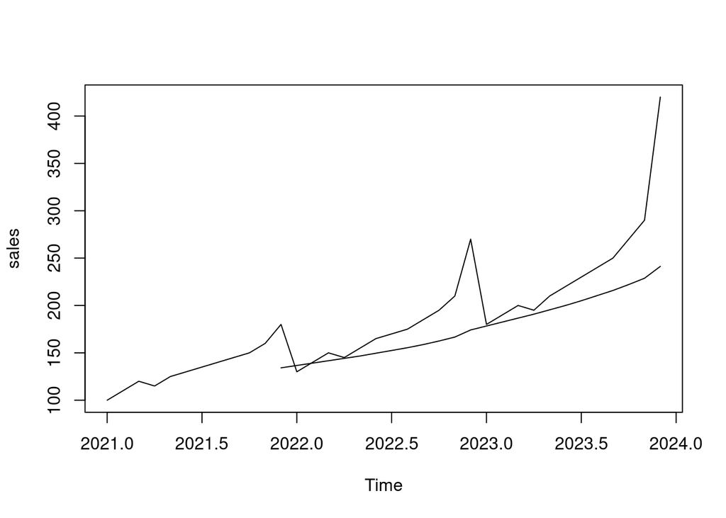

```r
plot(sales)
lines(smooth)
```

# 12. Regression in Time Series

```r
lm()
```

Regression identifies the relationship between:

```
Independent variables → Dependent variable
```

For example:

```
Advertising expenditure → Sales
```

R:

```r
model <- lm(sales ~ advertising)
summary(model)
```

`lm()` is R function used for regression analysis

# 13. Forecasting

The **main objective**.

> **“We have historical data. Can we use it to estimate what happens in the future?”**

That’s forecasting.

Example:

```
Past
Jan Feb Mar Apr May Jun
100 110 120 130 145 150
                  ↓
              MODEL
                  ↓
              Forecast
                  ↓
                 Jul
                160
```

We define forecasting as predicting future events from past data and introduces exponential smoothing for short-term forecasting.

# 14. Three Types of Exponential Smoothing

This can be taught using one simple table.

| Method | Handles |
| --- | --- |
| Simple Exponential Smoothing | Level |
| Holt’s | Level + Trend |
| Holt-Winters | Level + Trend + Seasonality |

## Simple Exponential Smoothing

Use when there is approximately:

```
NO strong trend
NO seasonality
```

It estimates the current **level** and produces a short-term forecast.

```r
library(forecast)
```

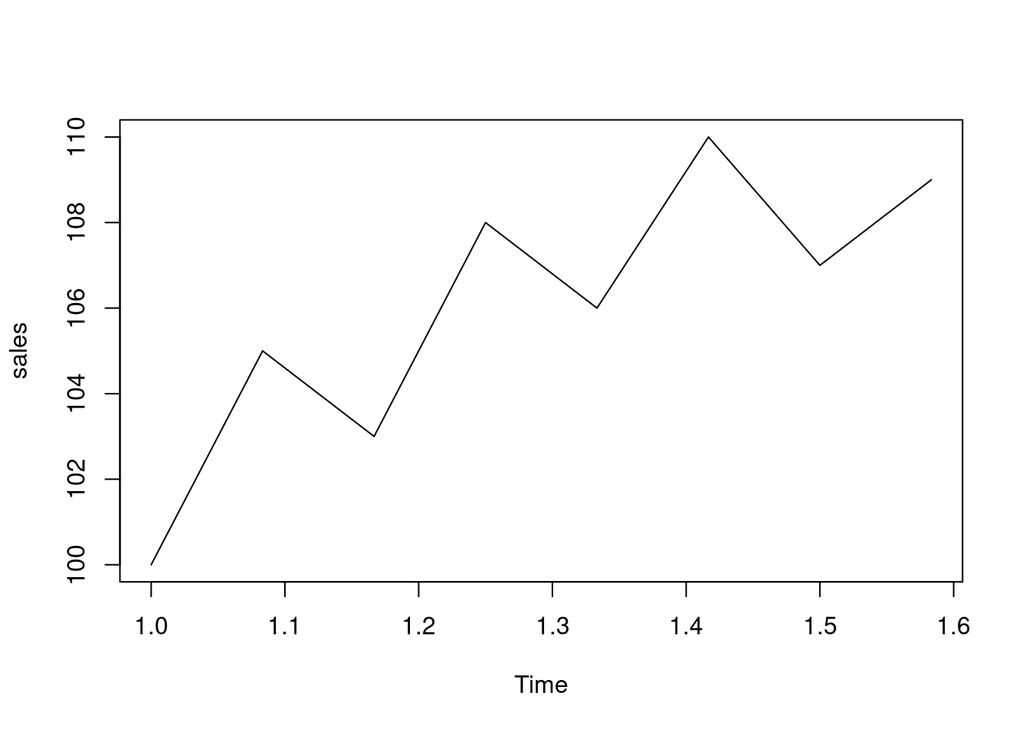

```r
sales <- ts(c(100,105,103,108,106,110,107,109),
            frequency = 12)

plot(sales)
```

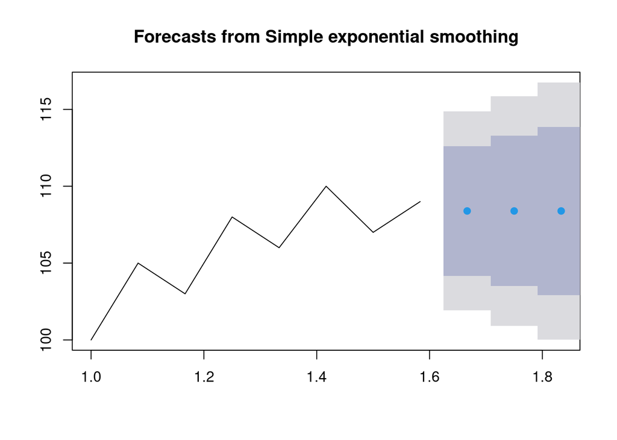

```r
# h means the number of future periods you want to forecast.
fit <- ses(sales, h = 3)

plot(fit)
```

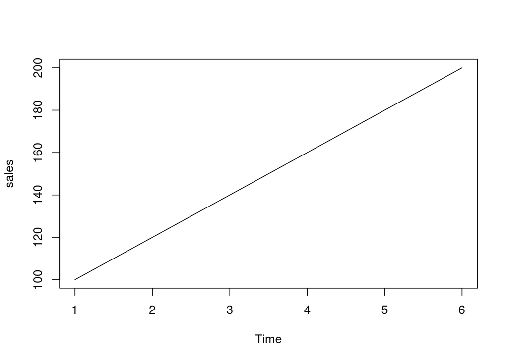

```r
sales <- ts(c(100,120,140,160,180,200))

plot(sales)
```

```r
fit <- ses(sales, h = 3)

forecast(fit)
```

```
##   Point Forecast    Lo 80    Hi 80    Lo 95    Hi 95
## 7            200 176.6022 223.3978 164.2161 235.7839
## 8            200 166.9105 233.0895 149.3939 250.6061
## 9            200 159.4738 240.5262 138.0205 261.9795
```

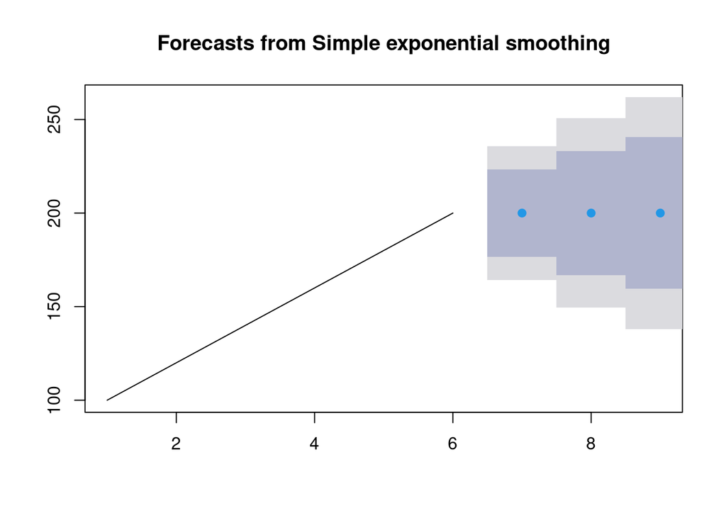

```r
plot(fit)
```

## Holt’s Exponential Smoothing

Use when:

```
Trend exists
Seasonality doesn't
```

It estimates:

```
Level + Slope/Trend
```

alpha and beta control the level and slope respectively.

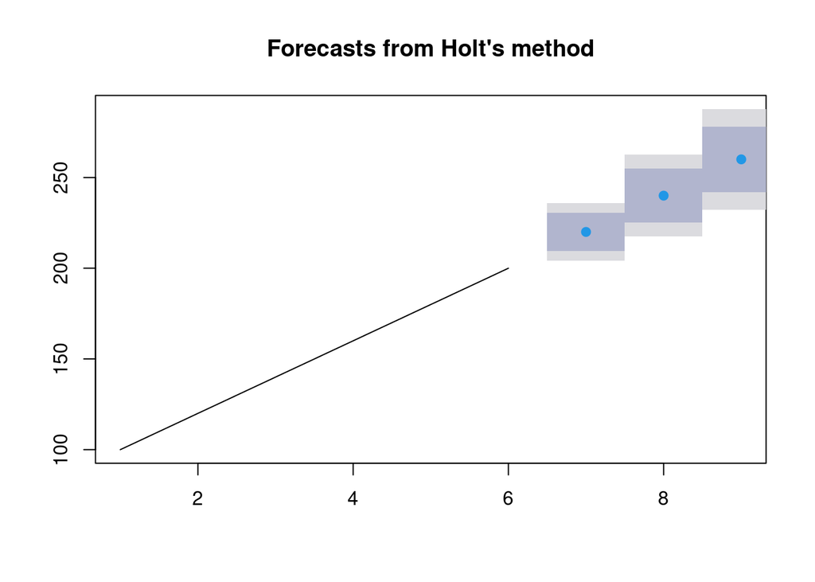

```r
fit <- holt(sales, h = 3)

plot(fit)
```

## Holt-Winters

Use when:

```
Trend + Seasonality
```

It estimates:

```
Level
+
Trend
+
Seasonality
```

```
alpha → level
beta  → trend
gamma → seasonality
```

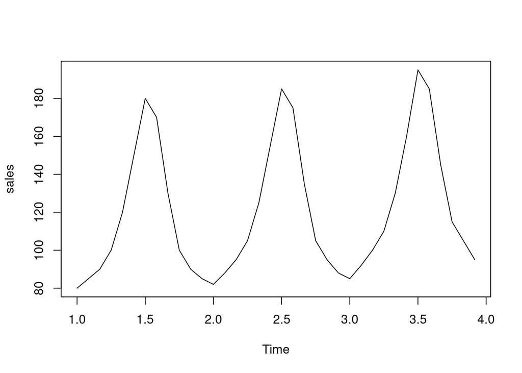

```r
sales <- ts(
  c(80,85,90,100,120,150,180,170,130,100,90,85,
    82,88,95,105,125,155,185,175,135,105,95,88,
    85,92,100,110,130,160,195,185,145,115,105,95),
  frequency = 12
)

plot(sales)
```

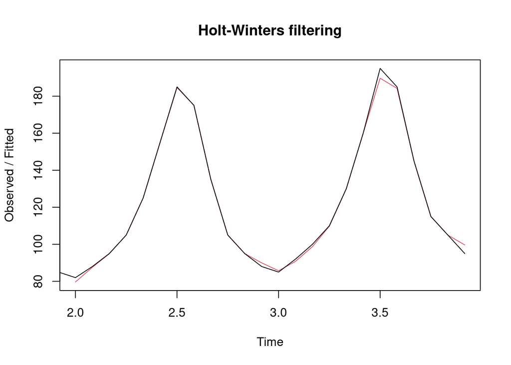

```r
fit <- HoltWinters(sales)

plot(fit)
```

```r
print(fit)
```

```
## Holt-Winters exponential smoothing with trend and additive seasonal component.
##
## Call:
## HoltWinters(x = sales)
##
## Smoothing parameters:
##  alpha: 0.830213
##  beta : 0
##  gamma: 1
##
## Coefficients:
##            [,1]
## a   127.9748559
## b     0.3996212
## s1  -34.9892143
## s2  -29.4052926
## s3  -22.8682967
## s4  -13.4705023
## s5    6.0799902
## s6   35.7149581
## s7   65.9072370
## s8   54.8463851
## s9   14.3949913
## s10 -16.0148974
## s11 -26.4282614
## s12 -32.9748559
```

### **Fitting with Holt-Winters**

Before we predict values in the future, we’ll need to create a fit to the data. In the most basic method, we can simply call the Holt-Winters function and let R figure out the tuning parameters on it’s own. We also have the opportunity to tune the fit manually by setting tuning variables:

- `alpha`: the “base value”. Higher alpha puts more weight on the most recent observations.
- `beta`: the “trend value”. Higher beta means the trend slope is more dependent on recent trend slopes. If set to `FALSE`, the function will do exponential smoothing.
- `gamma`: the “seasonal component”. Higher gamma puts more weighting on the most recent seasonal cycles. If set to `FALSE`, an non-seasonal model is fitted.

Holt-Winters is useful when the series has a clear: **Level + Trend + Seasonality** For example, monthly ice-cream sales

### Situation Hotel bookings

```
Bookings
   |       /\          /\
   |      /  \        /  \
   |_____/    \______/    \____
   +--------------------------> Time
```

There is a strong repeating seasonal pattern.**Holt-Winters is a natural model to try.**

ARIMA is particularly useful when the **dependence between observations over time** is important. For example, suppose daily electricity demand behaves like this. todays demand=function of day before yestarday demand, yestarday demand

# 15. ARIMA

After exponential smoothing, we moves to **ARIMA**.

### Stock/financial-type time series

The pattern may look more like:

```
        /\    /\
   /\  /  \__/  \___
__/  \/             \/\__
                         \_
```

There may not be a stable seasonal pattern.

Instead, relationships among recent observations and changes may be more important. **ARIMA-type models become useful to consider.**

ARIMA stands for:

> **AutoRegressive Integrated Moving Average**

It is represented as:

```
ARIMA(p, d, q)
```

where:

```
p = AR order
d = differencing order
q = MA order
```

ARIMA is particularly concerned with the autocorrelation structure of a stationary time series.

# 16. Why Stationarity?

A stationary series is roughly one whose statistical behaviour is reasonably stable over time.

Suppose:

```
100
110
120
130
140
150
```

The mean is continuously changing.

So we may need **differencing**.

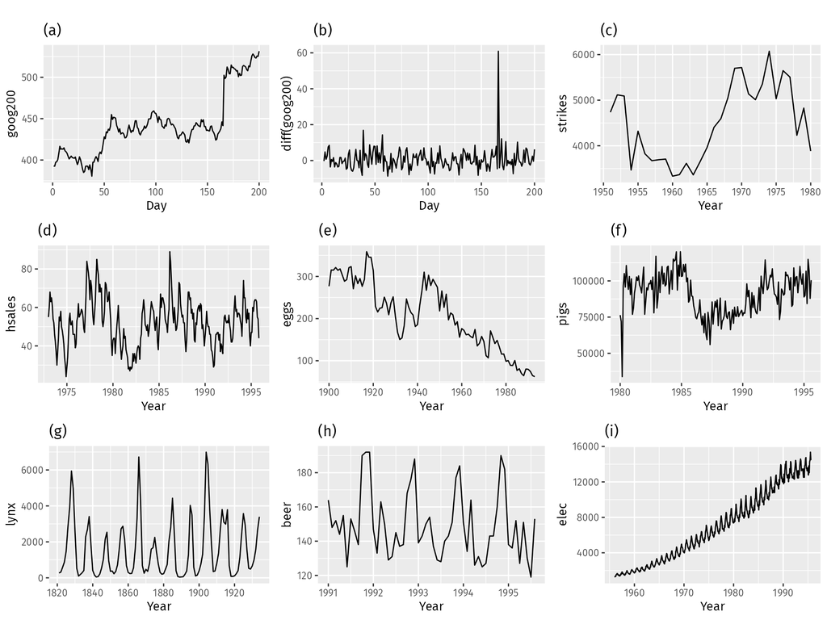

Figure above: Which of these series are stationary? (a) Google stock price for 200 consecutive days; (b) Daily change in the Google stock price for 200 consecutive days; (c) Annual number of strikes in the US; (d) Monthly sales of new one-family houses sold in the US; (e) Annual price of a dozen eggs in the US (constant dollars); (f) Monthly total of pigs slaughtered in Victoria, Australia; (g) Annual total of lynx trapped in the McKenzie River district of north-west Canada; (h) Monthly Australian beer production; (i) Monthly Australian electricity production.

Consider the nine series plotted in Figure above. Which of these do you think are stationary?

Obvious seasonality rules out series (d), (h) and (i). Trends and changing levels rules out series (a), (c), (e), (f) and (i). Increasing variance also rules out (i). That leaves only (b) and (g) as stationary series.

At first glance, the strong cycles in series (g) might appear to make it non-stationary. But these cycles are aperiodic — they are caused when the lynx population becomes too large for the available feed, so that they stop breeding and the population falls to low numbers, then the regeneration of their food sources allows the population to grow again, and so on. In the long-term, the timing of these cycles is not predictable. Hence the series is stationary.

reference book https://otexts.com/fpp2/

# 17. Differencing

Suppose:

```
Sales:
100
110
120
130
```

First difference:

```
110 - 100 = 10
120 - 110 = 10
130 - 120 = 10
```

So:

```
10
10
10
```

R:

```r
diff(sales)
```

differencing as a first step toward obtaining a stationary series for ARIMA and uses `diff()` to perform it.

intuitive understanding of the **d** in ARIMA.

# Understanding the Individual Components of ARIMA

ARIMA is a time-series forecasting method used to predict future values based on patterns in historical data.

**ARIMA = AutoRegressive Integrated Moving Average**

It has three components:

- **AR (p):** Autoregressive
- **I (d):** Integrated
- **MA (q):** Moving Average

The general model is written as:

$$\boxed{\operatorname{ARIMA}(p,d,q)}$$

## 1. AR — Autoregressive component (p)

### What does AR mean?

The autoregressive component predicts the current value using previous values of the same time series.

For example, imagine a company’s monthly sales:

| Month | Sales |
| --- | --- |
| January | 100 |
| February | 110 |
| March | 108 |
| April | 115 |
| May | 113 |

The sales in May may be related to sales in April, March, and earlier months.

The basic idea is:

**Past sales → Current sales**

For example:

$$Y_t = c + \phi_1 Y_{t-1} + \epsilon_t$$

Where:

- $Y_t$ = sales in the current month.
- $Y_{t-1}$ = sales in the previous month.
- $c$ = constant.
- $\phi_1$ = coefficient describing the relationship with the previous month’s sales.
- $\epsilon_t$ = random error.

This is an **AR(1)** model because it uses one previous observation.

### What does p mean?

The parameter $p$ specifies the number of autoregressive terms.

| Model | Meaning |
| --- | --- |
| AR(1) | Uses the previous observation |
| AR(2) | Uses the previous two observations |
| AR(3) | Uses the previous three observations |

For example, AR(2) uses:

$$Y_t=c+\phi_1Y_{t-1}+\phi_2Y_{t-2}+\epsilon_t$$

It considers sales from both the previous month and the month before that.

### Example

```r
sales <- ts(
  c(100, 110, 108, 115, 113, 120, 118, 125),
  frequency = 1
)

# Fit an AR(1) model
model_ar <- arima(sales, order = c(1, 0, 0))

model_ar
```

```
##
## Call:
## arima(x = sales, order = c(1, 0, 0))
##
## Coefficients:
##          ar1  intercept
##       0.7356    113.163
## s.e.  0.3199      6.104
##
## sigma^2 estimated as 35.13:  log likelihood = -25.98,  aic = 57.96
```

Here:

```
order = c(1, 0, 0)
```

means:

- `p = 1`: Include one autoregressive term.
- `d = 0`: Do not difference the data.
- `q = 0`: Do not include moving-average error terms.

**Industry example:** A retailer’s current sales may be strongly related to its previous month’s sales.

**Remember: AR = use previous observations.**

## 2. I — Integrated component (d)

### What problem does it solve?

Many time series contain a trend.

For example, suppose a mobile application gains 20 new subscribers every month.

| Month | Subscribers |
| --- | --- |
| January | 100 |
| February | 120 |
| March | 140 |
| April | 160 |
| May | 180 |

The series has an upward trend.

Some ARIMA models require the series to be stationary, meaning its statistical properties, such as mean and variance, are stable over time.

**Differencing is one way to remove a trend and help make a series stationary.**

### What is differencing?

Differencing calculates the difference between consecutive observations.

$$\boxed{\Delta Y_t=Y_t-Y_{t-1}}$$

For our example:

| Month | Subscribers | First difference |
| --- | --- | --- |
| January | 100 | — |
| February | 120 | 20 |
| March | 140 | 20 |
| April | 160 | 20 |
| May | 180 | 20 |

After differencing, the series becomes:

$$20,\ 20,\ 20,\ 20$$

The upward trend has been removed, leaving a constant difference.

### R example

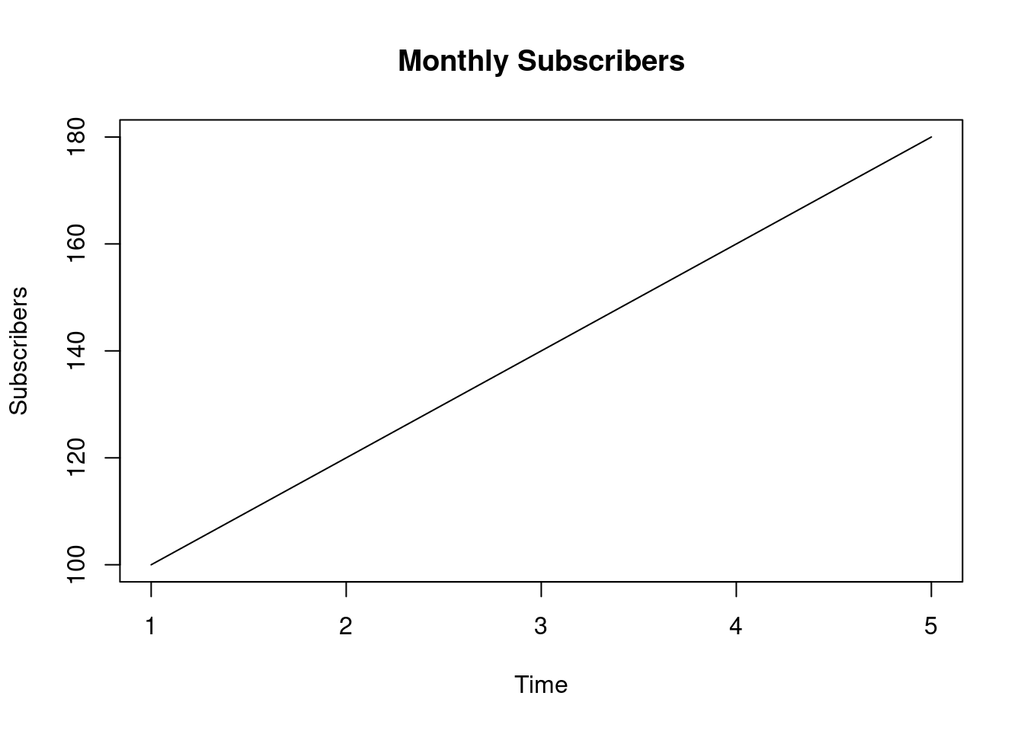

```r
subscribers <- ts(
  c(100, 120, 140, 160, 180),
  frequency = 1
)

# Original series
plot(subscribers,
     main = "Monthly Subscribers",
     ylab = "Subscribers")
```

```r
# First difference
diff_subscribers <- diff(subscribers)

print(diff_subscribers)
```

```
## Time Series:
## Start = 2
## End = 5
## Frequency = 1
## [1] 20 20 20 20
```

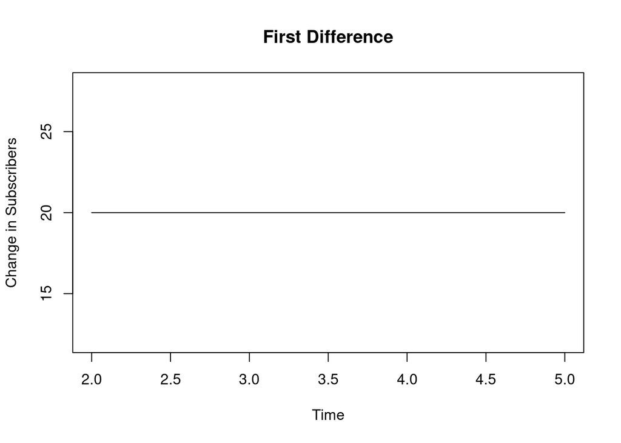

```r
plot(diff_subscribers,
     main = "First Difference",
     ylab = "Change in Subscribers")
```

The output of:

```
diff(subscribers)
```

is:

```
20 20 20 20
```

### What does d mean?

The parameter `d` specifies the number of times ordinary differencing is applied.

| Value of d | Meaning |
| --- | --- |
| `d = 0` | No differencing |
| `d = 1` | Difference once |
| `d = 2` | Difference twice |

For example:

```
# ARIMA(1,1,0)
arima(subscribers, order = c(1, 1, 0))
```

Here, `d = 1` tells R to apply first differencing when fitting the ARIMA model.

**Industry example:** A company whose customer base grows over time may use differencing to model changes in its customer numbers rather than the increasing absolute values.

**Remember: I = difference the data to address non-stationarity.**

*Important:* Differencing does not guarantee stationarity. The series should be examined to determine whether differencing is appropriate and whether further transformations are needed.

## 3. MA — Moving Average component (q)

### What does MA mean in ARIMA?

This is the component that often confuses students.

The MA component of ARIMA is **not the same as a simple moving average such as `SMA()`**.

In ARIMA, MA uses previous forecast errors to model the current observation.

Suppose a company forecasts its daily orders.

| Day | Actual orders | Forecast orders | Forecast error |
| --- | --- | --- | --- |
| Monday | 100 | 95 | +5 |
| Tuesday | 110 | 105 | +5 |
| Wednesday | 108 | 112 | -4 |
| Thursday | 115 | 110 | +5 |

The forecast error is:

$$e_t=Y_t-\hat{Y}_t$$

For example, Monday’s error is:

$$100-95=5$$

An MA model uses previous forecast errors as part of its prediction.

For an MA(1) model:

$$Y_t=\mu+\epsilon_t+\theta_1\epsilon_{t-1}$$

Where:

- $Y_t$ = current observation.
- $\mu$ = mean or baseline.
- $\epsilon_t$ = current random error.
- $\epsilon_{t-1}$ = previous period’s error.
- $\theta_1$ = coefficient for the previous error.

Conceptually:

**Previous forecast errors → Current value**

### What does q mean?

The parameter `q` specifies the number of lagged error terms.

| Model | Meaning |
| --- | --- |
| MA(1) | Uses one lagged error |
| MA(2) | Uses two lagged errors |
| MA(3) | Uses three lagged errors |

### R example

```r
sales <- ts(
  c(100, 110, 108, 115, 113, 120, 118, 125),
  frequency = 1
)

# Fit an MA(1) model
model_ma <- arima(sales, order = c(0, 0, 1))

model_ma
```

```
##
## Call:
## arima(x = sales, order = c(0, 0, 1))
##
## Coefficients:
##          ma1  intercept
##       0.2684   113.5482
## s.e.  0.2848     3.0160
##
## sigma^2 estimated as 47.59:  log likelihood = -26.84,  aic = 59.68
```

Here:

```
order = c(0, 0, 1)
```

means:

- `p = 0`: No autoregressive terms.
- `d = 0`: No differencing.
- `q = 1`: One lagged error term.

**Industry example:** Suppose a retailer’s forecasting errors have a short-term pattern because of temporary delivery disruptions. An MA component may help model short-lived error dependence, provided the data supports that structure.

**Remember: MA = use previous forecast errors, not moving averages of the raw observations.**

# 4. Combine the components: ARIMA(p, d, q)

Now let’s put all three together.

Suppose we want to forecast monthly sales.

```
sales <- ts(
  c(100, 110, 108, 115, 113, 120, 118, 125,
    123, 130, 128, 135),
  frequency = 1
)
```

### Model A: ARIMA(1,0,0)

```
model1 <- arima(sales, order = c(1, 0, 0))
```

This model has:

- One autoregressive term.
- No differencing.
- No moving-average error terms.

It uses the relationship between the current value and the previous value.

### Model B: ARIMA(0,1,0)

```
model2 <- arima(sales, order = c(0, 1, 0))
```

This model has:

- No autoregressive terms.
- First differencing.
- No moving-average error terms.

It models the first differences rather than the original levels.

### Model C: ARIMA(0,0,1)

```
model3 <- arima(sales, order = c(0, 0, 1))
```

This model has:

- No autoregressive terms.
- No differencing.
- One moving-average error term.

It uses the previous error to help model the current observation.

### Model D: ARIMA(1,1,1)

```
model4 <- arima(sales, order = c(1, 1, 1))
```

This combines all three components:

- `p = 1`: Autoregressive term.
- `d = 1`: First differencing.
- `q = 1`: Moving-average error term.

This is a more flexible model, but it is **not automatically better** than the simpler models.

# 5. Forecast future values

Once we fit a model, we can forecast future observations.

For example:

```
library(forecast)

model <- auto.arima(sales)

future <- forecast(model, h = 3)

print(future)

plot(future,
     main = "Forecast of Monthly Sales",
     xlab = "Time",
     ylab = "Sales")
```

Here:

- `auto.arima(sales)` selects an ARIMA model based on the data and its selection criteria.
- `h = 3` requests forecasts for the next three periods.
- Because the example uses `frequency = 1`, these are simply the next three observations; they do not represent three months unless the observations are monthly.

In real applications, the best model should also be checked using forecast accuracy on held-out observations.

# 6. Comparison

| Component | Parameter | Main question | Example |
| --- | --- | --- | --- |
| AR | `p` | Are current values related to previous observations? | This month’s sales depend on last month’s sales. |
| I | `d` | Does the series need differencing to address a trend or other non-stationarity? | Model monthly changes in subscribers. |
| MA | `q` | Are previous forecast errors useful for predicting the current value? | Model short-term dependence in forecast errors. |

# 18. ACF and PACF

Once the series is stationary, we need to understand the relationship between observations at different time lags.

### ACF

```r
acf(x)
```

ACF = **Autocorrelation Function**

It helps examine correlation between observations at different lags.

### PACF

```r
pacf(x)
```

PACF = **Partial Autocorrelation Function**

ACF and PACF are used to help select suitable values of `q` and `p`, respectively.

> **ACF → helps with q** **PACF → helps with p**

# Understanding ACF and PACF in Time Series Analysis

ACF and PACF are important concepts in ARIMA modelling. They help us understand **how current observations are related to past observations** and help us identify possible values of `p` and `q` in an ARIMA model.

Let’s understand them using simple examples suitable for B.Tech students.

## 1. What is ACF?

**ACF = Autocorrelation Function**

Autocorrelation measures the relationship between a time series and its own past values.

For example, consider monthly sales at an e-commerce company.

| Month | Sales |
| --- | --- |
| January | 100 |
| February | 110 |
| March | 108 |
| April | 115 |
| May | 113 |
| June | 120 |
| July | 118 |
| August | 125 |

We might ask:

- Are January’s sales related to February’s sales?
- Are sales this month related to sales two months ago?
- Does the relationship become weaker as we look further into the past?

ACF helps answer these questions.

### What is a lag?

A **lag** is the number of time periods separating two observations.

For monthly sales:

- **Lag 1:** Compare this month’s sales with the previous month’s sales.
- **Lag 2:** Compare this month’s sales with sales two months ago.
- **Lag 3:** Compare this month’s sales with sales three months ago.

For example, at lag 1, we compare:

| Current month | Previous month |
| --- | --- |
| February | January |
| March | February |
| April | March |
| May | April |

At lag 2, we compare:

| Current month | Two months earlier |
| --- | --- |
| March | January |
| April | February |
| May | March |
| June | April |

ACF calculates the correlation at each lag.

### A simple analogy

Imagine that today’s electricity demand is similar to yesterday’s demand.

If this relationship is strong, the autocorrelation at lag 1 will be high.

If today’s demand is also related to demand two days ago, the autocorrelation at lag 2 may also be high.

**Remember: ACF tells us how strongly observations are correlated with their past values at different lags.**

## 2. How do we calculate ACF in R?

R provides the `acf()` function.

Let’s create a small example using daily orders at an online shopping company.

```
# Daily orders
orders <- ts(c(
  100, 110, 108, 115, 113, 120,
  118, 125, 123, 130, 128, 135,
  133, 140, 138, 145, 143, 150,
  148, 155
))

# Plot the original data
plot(orders,
     type = "o",
     main = "Daily Orders",
     ylab = "Number of Orders",
     xlab = "Day")

# Calculate and plot ACF
acf(orders, main = "ACF of Daily Orders")
```

The ACF graph contains vertical bars corresponding to different lags.

- The bar at **lag 0** is always 1.
- The bar at **lag 1** shows the correlation between observations one period apart.
- The bar at **lag 2** shows the correlation between observations two periods apart.
- The remaining bars show correlations at higher lags.

The dashed blue lines indicate approximate 95% confidence limits under the usual white-noise reference assumptions. Bars extending beyond these limits suggest statistically significant autocorrelation, although the interpretation requires care when the series has a trend or seasonality.

For our example, orders generally increase over time. Consequently, several lags may show strong autocorrelation.

**Important:** A trend can produce high ACF values at several lags. Before using ACF to identify an ARIMA model, we may need to remove the trend or otherwise make the series stationary.

## 3. What is PACF?

**PACF = Partial Autocorrelation Function**

PACF measures the relationship between the current observation and an observation at a particular lag **after accounting for the linear relationships involving the intervening lags**.

This distinction is important.

Suppose today’s sales are related to yesterday’s sales, and yesterday’s sales are related to the sales two days ago.

Then today’s sales may also appear related to sales two days ago simply because of the relationship passing through yesterday’s sales.

PACF attempts to isolate the additional relationship at lag 2 after accounting for lag 1.

### A simple example

Imagine:

```
Sales 2 days ago ──→ Yesterday's sales ──→ Today's sales
```

Suppose:

- Today’s sales are strongly related to yesterday’s sales.
- Yesterday’s sales are related to sales two days ago.
- Once we account for yesterday’s sales, sales two days ago add little extra information.

In this situation, the ACF at lag 2 might be substantial, but the PACF at lag 2 could be small.

This is the intuition behind partial autocorrelation.

**Remember: ACF measures the overall correlation at a lag; PACF measures the additional linear relationship at that lag after accounting for shorter lags.**

### Calculate PACF in R

```
pacf(orders, main = "PACF of Daily Orders")
```

You can also display both graphs separately:

```
acf(orders, main = "Autocorrelation Function")
pacf(orders, main = "Partial Autocorrelation Function")
```

## 4. The important difference between ACF and PACF

| Feature | ACF | PACF |
| --- | --- | --- |
| Full form | Autocorrelation Function | Partial Autocorrelation Function |
| What does it measure? | Correlation between observations separated by a lag | Additional correlation at a lag after accounting for shorter lags |
| Example at lag 2 | Relationship between today’s sales and sales two days ago | Relationship after accounting for the intervening lag, especially lag 1 |
| Common ARIMA use | Helps identify candidate MA order, `q` | Helps identify candidate AR order, `p` |
| R function | `acf()` | `pacf()` |

### An easy analogy

Suppose a student scores well in an examination.

The score may be related to:

- The student’s preparation yesterday.
- The student’s preparation two days ago.
- The student’s preparation three days ago.

**ACF:** How strongly are scores related across different time gaps?

**PACF:** Does the score from two days ago have an additional relationship with today’s score after accounting for yesterday’s score?

## 5. How do ACF and PACF help identify ARIMA models?

This is their most important application.

Recall:

$$ARIMA(p,d,q)$$

- `p` = autoregressive order.
- `d` = differencing order.
- `q` = moving-average order.

For a basic introductory lesson, students can learn these common patterns:

| Model | Typical ACF pattern | Typical PACF pattern |
| --- | --- | --- |
| AR(1) | Gradually tails off | Cuts off after lag 1 |
| AR(2) | Gradually tails off | Cuts off after lag 2 |
| MA(1) | Cuts off after lag 1 | Gradually tails off |
| MA(2) | Cuts off after lag 2 | Gradually tails off |

Here, *cuts off* means that correlations beyond a certain lag are theoretically zero, while *tails off* means they gradually approach zero.

In actual sample graphs, these patterns are rarely perfect. ACF and PACF are tools for identifying **candidate models**, not definitive rules for selecting a model.

# 19. `auto.arima()`

Instead of manually trying different combinations of:

```
p
d
q
```

R provides:

```r
auto.arima()
```

`auto.arima()` automatically returns a candidate ARIMA model.

Example:

```r
model <- auto.arima(sales)
model
```